# lme4 convergence problem

Maxwell

2022-03-25

I sometimes encountered a convergence problem with `lme4` package. Here I will examine the convergence problem by the following guidance:  
https://m-clark.github.io/posts/2020-03-16-convergence/#remove-zero-random-effects

# 1 Preparations

## 1.1 Load libraries

## 1.2 Environment

```r
# rgb(73, 81, 112, maxColorValue = 255): "#495170"
col.1 <- crayons()["Blue Gray"]  # blue
col.2 <- crayons()["Caribbean Green"]  # green
col.3 <- crayons()["Razzmatazz"]  # red
scale.col.1 <- c(col.1, col.3)
font.1 <- "Candara"
theme_set(theme_bw(base_family = font.1))
options(dplyr.summarise.inform = TRUE)
```

# 2 Load DataSets

```r
df <- readRDS("input/convergence.RDS") %>%
   mutate(
      SUR.ID = factor(SUR.ID),
      replicate = factor(replicate),
      Unit = factor(1:n())
   )
```

```r
glimpse(df)
```

```
## Rows: 220
## Columns: 15
## $ SUR.ID           <fct> 10185, 10185, 10186, 10186, 10250, 10250, 10185, 1018~
## $ tm               <fct> CT, PT-04, PT-04, CT, PT-04, CT, PT-04, CT, PT-04, CT~
## $ ValidDetections  <int> 0, 0, 6, 5, 1, 7, 0, 0, 5, 8, 7, 3, 0, 0, 1, 4, 1, 0,~
## $ CountDetections  <int> 0, 0, 7, 5, 3, 7, 0, 0, 5, 8, 8, 4, 0, 0, 1, 4, 1, 1,~
## $ FalseDetections  <int> 0, 0, 1, 0, 2, 0, 0, 0, 0, 0, 1, 1, 0, 0, 0, 0, 0, 1,~
## $ replicate        <fct> 1, 1, 1, 1, 1, 1, 1, 1, 1, 1, 1, 1, 1, 1, 1, 1, 1, 1,~
## $ Area             <fct> Drug Channel, Drug Channel, Drug Channel, Drug Channe~
## $ Day              <fct> 03/06/13, 03/06/13, 03/06/13, 03/06/13, 03/06/13, 03/~
## $ R.det            <dbl> 0.0000000, 0.0000000, 0.8571429, 1.0000000, 0.3333333~
## $ c.receiver.depth <dbl> -0.200, -0.200, -0.200, -0.200, -0.200, -0.200, -0.22~
## $ c.tm.depth       <dbl> 0.04280769, 0.04280769, 0.04280769, 0.04280769, 0.042~
## $ c.temp           <dbl> -4.095808, -4.095808, -4.095808, -4.095808, -4.095808~
## $ c.wind           <dbl> 1.275352, 1.275352, 1.275352, 1.275352, 1.275352, 1.2~
## $ c.distance       <int> -160, -160, -160, -160, -160, -160, -110, -110, -110,~
## $ Unit             <fct> 1, 2, 3, 4, 5, 6, 7, 8, 9, 10, 11, 12, 13, 14, 15, 16~
```

```r
view.table(df)
```

|  | SUR.ID | tm | ValidDetections | CountDetections | FalseDetections | replicate | Area | Day | R.det | c.receiver.depth | c.tm.depth | c.temp | c.wind | c.distance | Unit |
| --- | --- | --- | --- | --- | --- | --- | --- | --- | --- | --- | --- | --- | --- | --- | --- |
| 1 | 10185 | CT | 0 | 0 | 0 | 1 | Drug Channel | 03/06/13 | 0 | -0.2 | 0.042807692 | -4.095807692 | 1.27535159 | -160 | 1 |
| 2 | 10185 | PT-04 | 0 | 0 | 0 | 1 | Drug Channel | 03/06/13 | 0 | -0.2 | 0.042807692 | -4.095807692 | 1.27535159 | -160 | 2 |
| 3 | 10186 | PT-04 | 6 | 7 | 1 | 1 | Drug Channel | 03/06/13 | 0.857142857 | -0.2 | 0.042807692 | -4.095807692 | 1.27535159 | -160 | 3 |
| 4 | 10186 | CT | 5 | 5 | 0 | 1 | Drug Channel | 03/06/13 | 1 | -0.2 | 0.042807692 | -4.095807692 | 1.27535159 | -160 | 4 |
| 5 | 10250 | PT-04 | 1 | 3 | 2 | 1 | Drug Channel | 03/06/13 | 0.333333333 | -0.2 | 0.042807692 | -4.095807692 | 1.27535159 | -160 | 5 |
| 6 | 10250 | CT | 7 | 7 | 0 | 1 | Drug Channel | 03/06/13 | 1 | -0.2 | 0.042807692 | -4.095807692 | 1.27535159 | -160 | 6 |
| 7 | 10185 | PT-04 | 0 | 0 | 0 | 1 | Drug Channel | 03/06/13 | 0 | -0.22 | -0.282192308 | -4.220807692 | 1.27535159 | -110 | 7 |
| 8 | 10185 | CT | 0 | 0 | 0 | 1 | Drug Channel | 03/06/13 | 0 | -0.22 | -0.282192308 | -4.220807692 | 1.27535159 | -110 | 8 |
| 9 | 10186 | PT-04 | 5 | 5 | 0 | 1 | Drug Channel | 03/06/13 | 1 | -0.22 | -0.282192308 | -4.220807692 | 1.27535159 | -110 | 9 |
| 10 | 10186 | CT | 8 | 8 | 0 | 1 | Drug Channel | 03/06/13 | 1 | -0.22 | -0.282192308 | -4.220807692 | 1.27535159 | -110 | 10 |

[output cut: 90 more lines]

# 3 VIF

`GVIF of c.tm.depth is very high.`

```r
car::vif(lm(CountDetections ~ . -Unit -Day -FalseDetections, dat = df))
```

```
##                       GVIF Df GVIF^(1/(2*Df))
## SUR.ID            1.200902  2        1.046832
## tm                1.066227  1        1.032583
## ValidDetections   2.708644  1        1.645796
## replicate         1.057540  1        1.028368
## Area              5.795510  1        2.407387
## R.det             2.393891  1        1.547220
## c.receiver.depth  8.674740  1        2.945291
## c.tm.depth       13.438407  1        3.665843
## c.temp            2.956315  1        1.719394
## c.wind            3.041363  1        1.743950
## c.distance        2.065335  1        1.437127
```

# 4 Start from naive GLM

```r
glm.1 <- glm(
   cbind(ValidDetections, FalseDetections) ~
      tm:Area + tm:c.distance + c.distance:Area + c.tm.depth:Area +
      c.receiver.depth:Area + c.temp:Area + c.wind:Area + c.tm.depth +
      c.receiver.depth + c.temp + c.wind + tm + c.distance + Area + replicate +
      SUR.ID + Day,
  data = df,
  family = binomial(link = "logit")
)

summary(glm.1)
```

```
##
## Call:
## glm(formula = cbind(ValidDetections, FalseDetections) ~ tm:Area +
##     tm:c.distance + c.distance:Area + c.tm.depth:Area + c.receiver.depth:Area +
##     c.temp:Area + c.wind:Area + c.tm.depth + c.receiver.depth +
##     c.temp + c.wind + tm + c.distance + Area + replicate + SUR.ID +
##     Day, family = binomial(link = "logit"), data = df)
##
## Deviance Residuals:
##    Min      1Q  Median      3Q     Max
## -2.739   0.000   0.000   0.539   2.161
##
## Coefficients: (3 not defined because of singularities)
##                               Estimate Std. Error z value Pr(>|z|)
## (Intercept)                 -1.125e+01  6.504e+00  -1.730  0.08372 .
## c.tm.depth                  -8.406e-01  1.228e+00  -0.684  0.49376
## c.receiver.depth             7.026e+00  7.852e+00   0.895  0.37095
## c.temp                      -5.514e+00  2.538e+00  -2.172  0.02983 *
## c.wind                      -6.256e+00  3.349e+00  -1.868  0.06179 .
## tmPT-04                     -2.053e+00  4.961e-01  -4.139  3.5e-05 ***
## c.distance                  -3.685e-03  2.614e-03  -1.410  0.15864
## AreaFinger                   5.901e+01  2.775e+01   2.127  0.03346 *
## replicate2                   2.700e+00  1.161e+00   2.326  0.02000 *
## SUR.ID10186                 -2.227e-01  4.456e-01  -0.500  0.61721
## SUR.ID10250                 -2.995e-01  4.469e-01  -0.670  0.50281
## Day2/22/13                  -7.114e+01  3.463e+01  -2.054  0.03996 *
## Day2/26/13                   3.306e+00  1.134e+03   0.003  0.99767
## Day2/27/13                          NA         NA      NA       NA
## Day3/14/13                          NA         NA      NA       NA
## tmPT-04:AreaFinger           4.308e-01  6.066e-01   0.710  0.47759
## tmPT-04:c.distance          -5.332e-03  3.186e-03  -1.674  0.09419 .
## AreaFinger:c.distance        1.192e-02  3.855e-03   3.091  0.00199 **
## AreaFinger:c.tm.depth       -2.815e+00  4.731e+00  -0.595  0.55189
## AreaFinger:c.receiver.depth -3.211e+01  2.545e+01  -1.262  0.20708
## AreaFinger:c.temp            2.377e+00  1.902e+00   1.250  0.21141
## AreaFinger:c.wind                   NA         NA      NA       NA
## ---
## Signif. codes:  0 '***' 0.001 '**' 0.01 '*' 0.05 '.' 0.1 ' ' 1
##
## (Dispersion parameter for binomial family taken to be 1)
##
##     Null deviance: 334.57  on 137  degrees of freedom
## Residual deviance: 135.23  on 119  degrees of freedom
## AIC: 253.65
##
## Number of Fisher Scoring iterations: 17
```

- Due to multicollinearity, some coefficients resulted in NA.

```r
# glm.2 <- update(glm.1, . ~ . - Day)
glm.2 <- glm(
   cbind(ValidDetections, FalseDetections) ~
      # tm:Area + tm:c.distance + c.distance:Area + #c.tm.depth:Area +
      # c.receiver.depth:Area + c.temp:Area + c.wind:Area + #c.tm.depth +
      c.receiver.depth + c.temp + c.wind + tm + c.distance + Area + replicate +
      SUR.ID,
   data = df,
   family = binomial(link = "logit")
)
summary(glm.2)
```

```
##
## Call:
## glm(formula = cbind(ValidDetections, FalseDetections) ~ c.receiver.depth +
##     c.temp + c.wind + tm + c.distance + Area + replicate + SUR.ID,
##     family = binomial(link = "logit"), data = df)
##
## Deviance Residuals:
##     Min       1Q   Median       3Q      Max
## -3.5835   0.0000   0.0000   0.6149   2.2653
##
## Coefficients:
##                   Estimate Std. Error z value Pr(>|z|)
## (Intercept)       2.184748   0.571572   3.822 0.000132 ***
## c.receiver.depth -3.411525   0.846877  -4.028 5.62e-05 ***
## c.temp            0.215628   0.156064   1.382 0.167075
## c.wind            0.105406   0.122425   0.861 0.389244
## tmPT-04          -1.247609   0.274491  -4.545 5.49e-06 ***
## c.distance       -0.008242   0.001343  -6.138 8.36e-10 ***
## AreaFinger        1.174951   0.477719   2.460 0.013913 *
## replicate2       -0.309685   0.286754  -1.080 0.280156
## SUR.ID10186      -0.188820   0.427136  -0.442 0.658445
## SUR.ID10250      -0.236376   0.424614  -0.557 0.577742
## ---
## Signif. codes:  0 '***' 0.001 '**' 0.01 '*' 0.05 '.' 0.1 ' ' 1
##
## (Dispersion parameter for binomial family taken to be 1)
##
##     Null deviance: 334.57  on 137  degrees of freedom
## Residual deviance: 161.18  on 128  degrees of freedom
## AIC: 261.6
##
## Number of Fisher Scoring iterations: 6
```

Now it worked.

# 5 Inital GLME

```r
glme.1 <- glmer(
   cbind(ValidDetections, FalseDetections) ~
      tm:Area + tm:c.distance + c.distance:Area + c.tm.depth:Area +
      c.receiver.depth:Area + c.temp:Area + c.wind:Area + c.tm.depth +
      c.receiver.depth + c.temp + c.wind + tm + c.distance + Area + replicate +
      (1 | SUR.ID) + (1|Day) + (1|Unit),
   data = df,
   family = binomial(link = "logit")
)
```

```r
summary(glme.1)
```

```
## Generalized linear mixed model fit by maximum likelihood (Laplace
##   Approximation) [glmerMod]
##  Family: binomial  ( logit )
## Formula: cbind(ValidDetections, FalseDetections) ~ tm:Area + tm:c.distance +
##     c.distance:Area + c.tm.depth:Area + c.receiver.depth:Area +
##     c.temp:Area + c.wind:Area + c.tm.depth + c.receiver.depth +
##     c.temp + c.wind + tm + c.distance + Area + replicate + (1 |
##     SUR.ID) + (1 | Day) + (1 | Unit)
##    Data: df
##
##      AIC      BIC   logLik deviance df.resid
##    252.2    316.7   -107.1    214.2      201
##
## Scaled residuals:
##     Min      1Q  Median      3Q     Max
## -3.1180  0.0000  0.0000  0.3477  1.2952
##
## Random effects:
##  Groups Name        Variance  Std.Dev.
##  Unit   (Intercept) 4.633e-01 0.680671
##  Day    (Intercept) 9.071e-05 0.009524
##  SUR.ID (Intercept) 5.077e-05 0.007125
## Number of obs: 220, groups:  Unit, 220; Day, 5; SUR.ID, 3
##
## Fixed effects:
##                               Estimate Std. Error z value Pr(>|z|)
## (Intercept)                 -11.390772   7.141155  -1.595 0.110693
## c.tm.depth                   -1.019495   1.389185  -0.734 0.463022
## c.receiver.depth              6.807001   8.968934   0.759 0.447881
## c.temp                       -5.486139   2.792705  -1.964 0.049478 *
## c.wind                       -6.269909   3.711409  -1.689 0.091150 .
## tmPT-04                      -2.147568   0.566800  -3.789 0.000151 ***
## c.distance                   -0.004280   0.003004  -1.425 0.154247
## AreaFinger                   11.592351   7.252826   1.598 0.109971
## replicate2                    2.697594   1.258939   2.143 0.032133 *
## tmPT-04:AreaFinger            0.455949   0.689523   0.661 0.508450
## tmPT-04:c.distance           -0.005873   0.003672  -1.599 0.109722
## AreaFinger:c.distance         0.013072   0.004454   2.935 0.003338 **
## AreaFinger:c.tm.depth        -3.022152   4.990364  -0.606 0.544782
## AreaFinger:c.receiver.depth -34.882043  16.932764  -2.060 0.039395 *
## AreaFinger:c.temp             2.193418   1.867228   1.175 0.240118
## AreaFinger:c.wind             8.349670   4.157960   2.008 0.044631 *
## ---
## Signif. codes:  0 '***' 0.001 '**' 0.01 '*' 0.05 '.' 0.1 ' ' 1
## optimizer (Nelder_Mead) convergence code: 0 (OK)
## Model failed to converge with max|grad| = 0.133199 (tol = 0.002, component 1)
## Model is nearly unidentifiable: very large eigenvalue
##  - Rescale variables?
## Model is nearly unidentifiable: large eigenvalue ratio
##  - Rescale variables?
```

```r
glme.1@optinfo$conv$lme4$messages[[1]]
```

```
## [1] "Model failed to converge with max|grad| = 0.133199 (tol = 0.002, component 1)"
```

Seems to fail in convergence…

# 6 GLME w/o cross terms

```r
glme.2 <- glmer(
   cbind(ValidDetections, FalseDetections) ~
      # tm:Area + tm:c.distance + c.distance:Area + #c.tm.depth:Area +
      # c.receiver.depth:Area + c.temp:Area + c.wind:Area + #c.tm.depth +
      c.receiver.depth + c.temp + c.wind + tm + c.distance + Area + replicate +
      SUR.ID +
      (1 | Unit),
   data = df,
   family = binomial(link = "logit")
)
```

```r
summary(glme.2)
```

```
## Generalized linear mixed model fit by maximum likelihood (Laplace
##   Approximation) [glmerMod]
##  Family: binomial  ( logit )
## Formula: cbind(ValidDetections, FalseDetections) ~ c.receiver.depth +
##     c.temp + c.wind + tm + c.distance + Area + replicate + SUR.ID +
##     (1 | Unit)
##    Data: df
##
##      AIC      BIC   logLik deviance df.resid
##    258.5    295.9   -118.3    236.5      209
##
## Scaled residuals:
##     Min      1Q  Median      3Q     Max
## -3.6953  0.0000  0.0000  0.3622  1.1353
##
## Random effects:
##  Groups Name        Variance Std.Dev.
##  Unit   (Intercept) 0.895    0.946
## Number of obs: 220, groups:  Unit, 220
##
## Fixed effects:
##                   Estimate Std. Error z value Pr(>|z|)
## (Intercept)       2.387483   0.731683   3.263 0.001102 **
## c.receiver.depth -3.799496   1.075855  -3.532 0.000413 ***
## c.temp            0.246841   0.193032   1.279 0.200981
## c.wind            0.132352   0.150874   0.877 0.380360
## tmPT-04          -1.362802   0.361581  -3.769 0.000164 ***
## c.distance       -0.009081   0.001783  -5.093 3.53e-07 ***
## AreaFinger        1.224603   0.615476   1.990 0.046626 *
## replicate2       -0.386550   0.367575  -1.052 0.292974
## SUR.ID10186      -0.125211   0.546061  -0.229 0.818636
## SUR.ID10250      -0.197368   0.543580  -0.363 0.716538
## ---
## Signif. codes:  0 '***' 0.001 '**' 0.01 '*' 0.05 '.' 0.1 ' ' 1
##
## Correlation of Fixed Effects:
##             (Intr) c.rcv. c.temp c.wind tPT-04 c.dstn ArFngr rplct2 SUR.ID101
## c.rcvr.dpth -0.541
## c.temp       0.569 -0.782
## c.wind       0.537 -0.864  0.903
## tmPT-04     -0.216  0.133  0.023 -0.009
## c.distance  -0.090  0.159 -0.105 -0.050  0.210
## AreaFinger  -0.720  0.667 -0.757 -0.738 -0.096  0.088
## replicate2  -0.353  0.245 -0.334 -0.300  0.054  0.216  0.193
## SUR.ID10186 -0.625  0.026 -0.022  0.023 -0.042  0.041  0.266 -0.033
## SUR.ID10250 -0.645  0.074 -0.009  0.007 -0.012 -0.007  0.280 -0.064  0.763
## optimizer (Nelder_Mead) convergence code: 0 (OK)
## Model failed to converge with max|grad| = 0.117672 (tol = 0.002, component 1)
```

```r
glme.2@optinfo$conv$lme4$messages[[1]]
```

```
## [1] "Model failed to converge with max|grad| = 0.117672 (tol = 0.002, component 1)"
```

Seems to fail to converge without change…

# 7 Check Items

## 7.1 Singularity

This is a mixed model-specific check, and in general, checking singularity goes along with removing zero random effects.  
These days, you will usually get a singularity warning when it is likely the case. In the past, Bolker suggested checking this problem as follows, but for this example concluded the result was not close enough to zero to be a real concern. The theta below are just our `random effect standard deviations`, and I would say that the ones besides Unit probably were not meaningfully different from zero.

```r
pars <- unlist(getME(glme.1, name = c("theta", "beta")))
print(pars)
```

```
##   theta.Unit.(Intercept)    theta.Day.(Intercept) theta.SUR.ID.(Intercept)
##              0.680670868              0.009524252              0.007125395
##                    beta1                    beta2                    beta3
##            -11.390771740             -1.019494587              6.807000605
##                    beta4                    beta5                    beta6
##             -5.486138517             -6.269908676             -2.147567524
##                    beta7                    beta8                    beta9
##             -0.004279670             11.592351492              2.697593559
##                   beta10                   beta11                   beta12
##              0.455949263             -0.005872928              0.013071953
##                   beta13                   beta14                   beta15
##             -3.022152241            -34.882042817              2.193418403
##                   beta16
##              8.349669798
```

Nowadays lme4 provides the function `isSingular` which uses the steps above to check the minimum value against some specified tolerance.

```r
isSingular(glme.1, tol = 1e-5)
```

```
## [1] FALSE
```

## 7.2 Compare Absolute and Scaled Gradient

For the mixed model setting, Bolker notes the following:

> One general problem is that large scaled gradients are often associated with small absolute gradients: we might decide that we are more interested in testing the (parallel) minimum of these two quantities.

We can do this as follows for the initial mixed model.

```r
derivs_init <- glme.1@optinfo$derivs
sc_grad_init <- with(derivs_init, solve(Hessian, gradient))

max(abs(sc_grad_init))
```

```
## [1] 1.519932
```

```r
max(pmin(abs(sc_grad_init), abs(derivs_init$gradient)))
```

```
## [1] 0.1331991
```

## 7.3 GLME w/o cross terms and c.distance

```r
glme.3 <- glmer(
   cbind(ValidDetections, FalseDetections) ~
      # tm:Area + tm:c.distance + c.distance:Area + #c.tm.depth:Area +
      # c.receiver.depth:Area + c.temp:Area + c.wind:Area + #c.tm.depth +
      c.receiver.depth + c.temp + c.wind + tm +
      # c.distance +
      Area + replicate + SUR.ID + (1 | Unit),
   data = df,
   family = binomial(link = "logit")
)
```

```r
summary(glme.3)
```

```
## Generalized linear mixed model fit by maximum likelihood (Laplace
##   Approximation) [glmerMod]
##  Family: binomial  ( logit )
## Formula: cbind(ValidDetections, FalseDetections) ~ c.receiver.depth +
##     c.temp + c.wind + tm + Area + replicate + SUR.ID + (1 | Unit)
##    Data: df
##
##      AIC      BIC   logLik deviance df.resid
##    283.7    317.7   -131.9    263.7      210
##
## Scaled residuals:
##     Min      1Q  Median      3Q     Max
## -1.9990  0.0000  0.0000  0.3046  1.0079
##
## Random effects:
##  Groups Name        Variance Std.Dev.
##  Unit   (Intercept) 1.792    1.339
## Number of obs: 220, groups:  Unit, 220
##
## Fixed effects:
##                  Estimate Std. Error z value Pr(>|z|)
## (Intercept)       2.61447    0.78908   3.313 0.000922 ***
## c.receiver.depth -3.90927    1.01336  -3.858 0.000114 ***
## c.temp            0.23321    0.16892   1.381 0.167407
## c.wind            0.16116    0.13012   1.239 0.215496
## tmPT-04          -1.27878    0.40971  -3.121 0.001801 **
## AreaFinger        1.64416    0.62640   2.625 0.008671 **
## replicate2       -0.10590    0.40121  -0.264 0.791811
## SUR.ID10186       0.06058    0.63356   0.096 0.923821
## SUR.ID10250      -0.17072    0.62770  -0.272 0.785636
## ---
## Signif. codes:  0 '***' 0.001 '**' 0.01 '*' 0.05 '.' 0.1 ' ' 1
##
## Correlation of Fixed Effects:
##             (Intr) c.rcv. c.temp c.wind tPT-04 ArFngr rplct2 SUR.ID101
## c.rcvr.dpth -0.408
## c.temp       0.455 -0.658
## c.wind       0.416 -0.778  0.832
## tmPT-04     -0.252  0.161  0.007 -0.045
## AreaFinger  -0.656  0.526 -0.656 -0.630 -0.092
## replicate2  -0.285  0.078 -0.184 -0.152  0.028  0.053
## SUR.ID10186 -0.683  0.012 -0.026  0.021 -0.040  0.310 -0.016
## SUR.ID10250 -0.702  0.083 -0.014 -0.003 -0.010  0.330 -0.044  0.762
## optimizer (Nelder_Mead) convergence code: 0 (OK)
## Model failed to converge with max|grad| = 0.0751011 (tol = 0.002, component 1)
```

```r
glme.3@optinfo$conv$lme4$messages[[1]]
```

```
## [1] "Model failed to converge with max|grad| = 0.0751011 (tol = 0.002, component 1)"
```

# 8 Restart GLME

```r
pars2 <- getME(glme.2, name = c("theta", "fixef"))
glme.2.update <- update(object = glme.2,
                        start = pars2,
                        control = glmerControl(optCtrl = list(maxfun = 2e4)))
```

```r
summary(glme.2.update)
```

```
## Generalized linear mixed model fit by maximum likelihood (Laplace
##   Approximation) [glmerMod]
##  Family: binomial  ( logit )
## Formula: cbind(ValidDetections, FalseDetections) ~ c.receiver.depth +
##     c.temp + c.wind + tm + c.distance + Area + replicate + SUR.ID +
##     (1 | Unit)
##    Data: df
## Control: glmerControl(optCtrl = list(maxfun = 20000))
##
##      AIC      BIC   logLik deviance df.resid
##    258.5    295.9   -118.3    236.5      209
##
## Scaled residuals:
##     Min      1Q  Median      3Q     Max
## -3.6705  0.0000  0.0000  0.3605  1.1288
##
## Random effects:
##  Groups Name        Variance Std.Dev.
##  Unit   (Intercept) 0.9052   0.9514
## Number of obs: 220, groups:  Unit, 220
##
## Fixed effects:
##                   Estimate Std. Error z value Pr(>|z|)
## (Intercept)       2.397263   0.735396   3.260 0.001115 **
## c.receiver.depth -3.827623   1.086660  -3.522 0.000428 ***
## c.temp            0.250803   0.195074   1.286 0.198555
## c.wind            0.135996   0.152499   0.892 0.372509
## tmPT-04          -1.377377   0.363266  -3.792 0.000150 ***
## c.distance       -0.009061   0.001786  -5.074 3.89e-07 ***
## AreaFinger        1.216071   0.619395   1.963 0.049609 *
## replicate2       -0.387457   0.369037  -1.050 0.293758
## SUR.ID10186      -0.117392   0.546829  -0.215 0.830019
## SUR.ID10250      -0.187391   0.544428  -0.344 0.730697
## ---
## Signif. codes:  0 '***' 0.001 '**' 0.01 '*' 0.05 '.' 0.1 ' ' 1
##
## Correlation of Fixed Effects:
##             (Intr) c.rcv. c.temp c.wind tPT-04 c.dstn ArFngr rplct2 SUR.ID101
## c.rcvr.dpth -0.545
## c.temp       0.573 -0.785
## c.wind       0.541 -0.866  0.904
## tmPT-04     -0.217  0.135  0.021 -0.010
## c.distance  -0.092  0.162 -0.109 -0.054  0.212
## AreaFinger  -0.723  0.670 -0.759 -0.741 -0.095  0.091
## replicate2  -0.356  0.251 -0.338 -0.306  0.054  0.217  0.198
## SUR.ID10186 -0.622  0.025 -0.022  0.024 -0.043  0.040  0.265 -0.032
## SUR.ID10250 -0.642  0.072 -0.008  0.008 -0.013 -0.009  0.279 -0.065  0.762
## optimizer (Nelder_Mead) convergence code: 0 (OK)
## Model failed to converge with max|grad| = 0.246919 (tol = 0.002, component 1)
```

```r
glme.2.update@optinfo$conv$lme4$messages[[1]]
```

```
## [1] "Model failed to converge with max|grad| = 0.246919 (tol = 0.002, component 1)"
```

# 9 GLME with BOBYQA through all iterations

```r
glme.2.update.opt <- update(
   object = glme.2,
   # start = pars2,
   control = glmerControl(
      optimizer = "bobyqa",
      optCtrl = list(maxfun = 2e4)
   )
)
```

```r
summary(glme.2.update.opt)
```

```
## Generalized linear mixed model fit by maximum likelihood (Laplace
##   Approximation) [glmerMod]
##  Family: binomial  ( logit )
## Formula: cbind(ValidDetections, FalseDetections) ~ c.receiver.depth +
##     c.temp + c.wind + tm + c.distance + Area + replicate + SUR.ID +
##     (1 | Unit)
##    Data: df
## Control: glmerControl(optimizer = "bobyqa", optCtrl = list(maxfun = 20000))
##
##      AIC      BIC   logLik deviance df.resid
##    258.5    295.9   -118.3    236.5      209
##
## Scaled residuals:
##     Min      1Q  Median      3Q     Max
## -3.6561  0.0000  0.0000  0.3628  1.1327
##
## Random effects:
##  Groups Name        Variance Std.Dev.
##  Unit   (Intercept) 0.9017   0.9496
## Number of obs: 220, groups:  Unit, 220
##
## Fixed effects:
##                   Estimate Std. Error z value Pr(>|z|)
## (Intercept)       2.373220   0.731817   3.243 0.001183 **
## c.receiver.depth -3.804452   1.078638  -3.527 0.000420 ***
## c.temp            0.248168   0.193556   1.282 0.199791
## c.wind            0.133391   0.151278   0.882 0.377906
## tmPT-04          -1.363393   0.362055  -3.766 0.000166 ***
## c.distance       -0.009079   0.001785  -5.086 3.65e-07 ***
## AreaFinger        1.225579   0.616756   1.987 0.046907 *
## replicate2       -0.383119   0.368064  -1.041 0.297921
## SUR.ID10186      -0.108441   0.546187  -0.199 0.842620
## SUR.ID10250      -0.179755   0.543671  -0.331 0.740923
## ---
## Signif. codes:  0 '***' 0.001 '**' 0.01 '*' 0.05 '.' 0.1 ' ' 1
##
## Correlation of Fixed Effects:
##             (Intr) c.rcv. c.temp c.wind tPT-04 c.dstn ArFngr rplct2 SUR.ID101
## c.rcvr.dpth -0.541
## c.temp       0.570 -0.783
## c.wind       0.538 -0.864  0.903
## tmPT-04     -0.215  0.133  0.023 -0.009
## c.distance  -0.089  0.159 -0.106 -0.050  0.210
## AreaFinger  -0.722  0.667 -0.757 -0.738 -0.096  0.088
## replicate2  -0.354  0.246 -0.335 -0.301  0.053  0.215  0.194
## SUR.ID10186 -0.623  0.024 -0.021  0.024 -0.043  0.039  0.266 -0.033
## SUR.ID10250 -0.644  0.072 -0.008  0.008 -0.013 -0.010  0.281 -0.065  0.762
```

```r
glme.2.update.opt@optinfo$conv$lme4$messages[[1]]
```

[output not shown]

# 10 Visualization

```r
glme.2.df <- glme.2 %>%
    broom.mixed::tidy(conf.int = T) %>%
    as.data.frame() %>%
    mutate_if(is.numeric, round, 5) %>%
    filter(!str_detect(term, "Intercept|sd__"))
glme.2.update.opt.df <- glme.2.update.opt %>%
    broom.mixed::tidy(conf.int = T) %>%
    as.data.frame() %>%
    mutate_if(is.numeric, round, 5) %>%
    filter(!str_detect(term, "Intercept|sd__"))
glm.2.df <- glm.2 %>%
   broom::tidy() %>%
   mutate(
      conf.low = estimate - std.error,
      conf.high = estimate + std.error,
   ) %>%
   filter(!str_detect(term, "Intercept|sd__"))
```

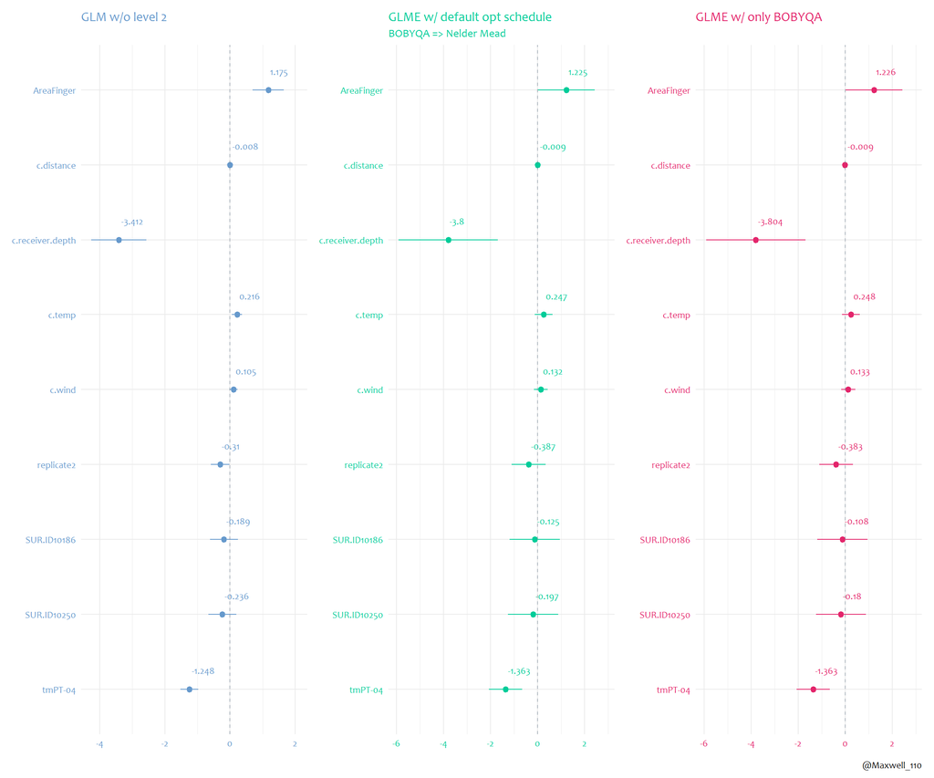

```r
glm.2.p <- glm.2.df %>%
   ggplot(mapping = aes(x = fct_rev(term), y = estimate,
                         ymin = conf.low, ymax = conf.high)) +
   geom_pointrange(color = col.1, size = 0.4) +
   geom_text(mapping = aes(x = fct_rev(term),
                           y = estimate,
                           label = round(estimate, 3)),
             check_overlap = TRUE, size = 3,
             family = "Candara", color = col.1,
             hjust = -0.1, nudge_x = 0.25) +
   geom_hline(yintercept = 0, color = "slategray",
              linetype = 2, alpha = 0.5) +
   lims(y = c(NA, max(glm.2.df$conf.high, na.rm = T) + 0.4)) +
   labs(x = NULL, y = NULL, title = "GLM w/o level 2") +
   coord_flip() +
   theme_minimal() +
   # theme_wsj() +
   theme(
      title = element_text(family = "Candara", color = col.1, size = 10),
      axis.text = element_text(family = "Candara", color = col.1, size = 8.5)
   )

glme.2.p <- glme.2.df %>%
   ggplot(mapping = aes(x = fct_rev(term), y = estimate,
                         ymin = conf.low, ymax = conf.high)) +
   geom_pointrange(color = col.2, size = 0.4) +
   geom_text(mapping = aes(x = fct_rev(term),
                           y = estimate,
                           label = round(estimate, 3)),
             check_overlap = TRUE, size = 3,
             family = "Candara", color = col.2,
             hjust = -0.1, nudge_x = 0.25) +
   geom_hline(yintercept = 0, color = "slategray",
              linetype = 2, alpha = 0.5) +
   lims(y = c(NA, max(glme.2.df$conf.high, na.rm = T) + 0.4)) +
   labs(x = NULL, y = NULL,
        title = "GLME w/ default opt schedule",
        subtitle = "BOBYQA => Nelder Mead") +
   coord_flip() +
   theme_minimal() +
   theme(
      title = element_text(family = "Candara", color = col.2, size = 10),
      axis.text = element_text(family = "Candara", color = col.2, size = 8.5)
   )

glme.2.update.opt.p <- glme.2.update.opt.df %>%
   ggplot(mapping = aes(x = fct_rev(term), y = estimate,
                         ymin = conf.low, ymax = conf.high)) +
   geom_pointrange(color = col.3, size = 0.4) +
   geom_text(mapping = aes(x = fct_rev(term),
                           y = estimate,
                           label = round(estimate, 3)),
             check_overlap = TRUE, size = 3,
             family = "Candara", color = col.3,
             hjust = -0.1, nudge_x = 0.25) +
   geom_hline(yintercept = 0, color = "slategray",
              linetype = 2, alpha = 0.5) +
   lims(y = c(NA, max(glme.2.update.opt.df$conf.high, na.rm = T) + 0.4)) +
   labs(x = NULL, y = NULL, title = "GLME w/ only BOBYQA") +
   coord_flip() +
   theme_minimal() +
   theme(
      title = element_text(family = "Candara", color = col.3, size = 10),
      axis.text = element_text(family = "Candara", color = col.3, size = 8.5)
   )

pw <- glm.2.p + glme.2.p + glme.2.update.opt.p
pw + patchwork::plot_annotation(
   caption = "@Maxwell_110"
)
```

```r
ggsave("fig/lme4-convergence_01.png", dpi = 300, width = 12, height = 10)
```